# Indel Filtering and QC Report

Luka Culibrk

2024-05-03

## Data and filtering overview

Indel variant callers already apply many filters based on sequence quality, mapping quality, and other metrics. These mutations are already filtered out here.

Here we show a general overview of **post-hoc** filtering. Unlike SBS mutations, germline/artifact indel profiles are not obvious, so we approach filtering through sensibility and orthogonal experience from SBS mutations. To this end, we apply essentially the same filters as we do in SBS.

Below we begin by plotting out the different categories of filters to visualize their proportions across samples in the Maciejowski Lung collaboration study.

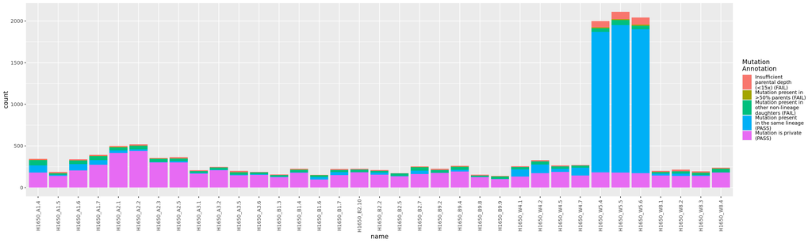

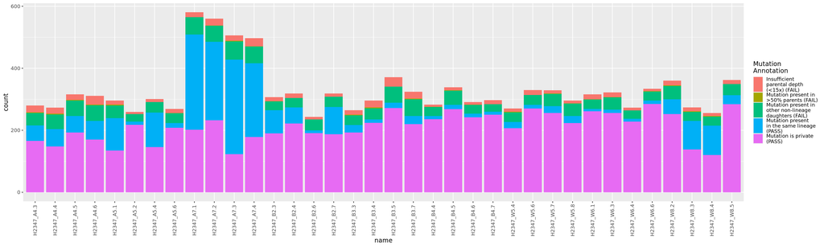

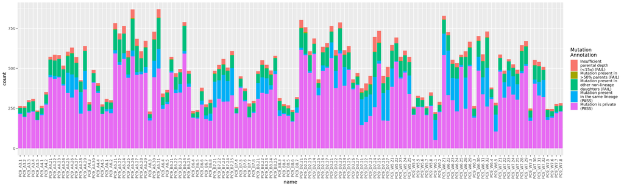

## ID profile of private daughter mutations by genotype

These mutations passed all QC metrics (discussed below), and were private to each daughter clone. Use this figure to compare with the later figures. These mutations are high quality and represent our best estimate for what ground truth “true positive” mutations look like.

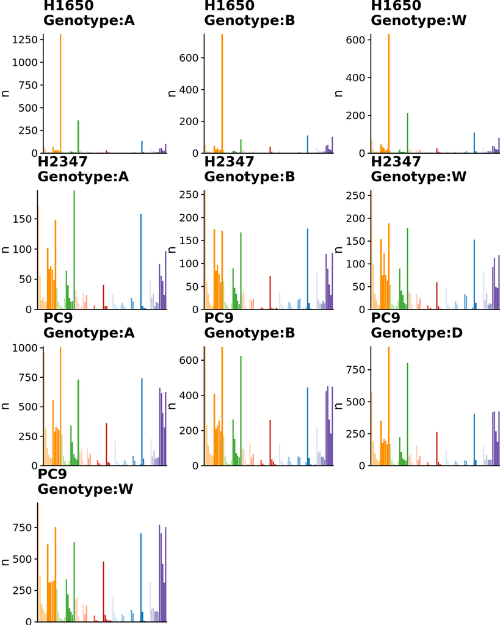

## First category - mutations of insufficient parental depth

We first filter out mutations that are covered by <15 reads in the parent. This is to ensure that for each mutation, we have sufficient power to be confident that the mutation is not present in the parent. This corresponds to a roughly one in 32000 chance for a daughter mutation to be present in the parent despite a lack of sequence evidence. Based on these plots and the previous plots of unique mutations, it is clear that these mutations exhibit different patterns and are likely to be artifactural or pre-existing.

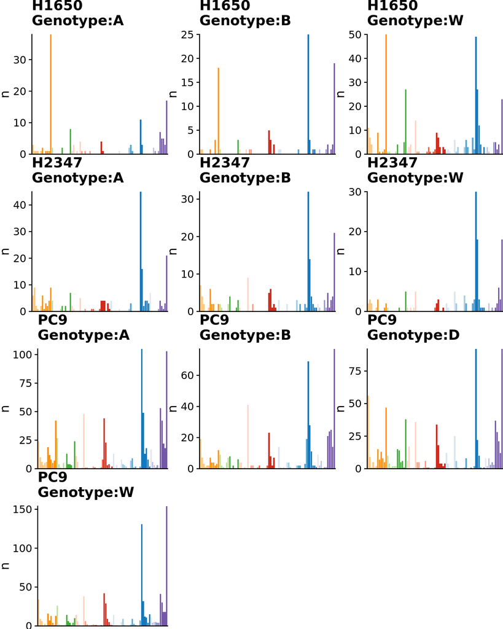

## Second category - Mutations present in >50% of all parents.

These mutations are clearly pre-existing to some degree, because they were recurrently identified in parents. In SBS, this category was self-evident based on mutational patterns. In this case, the mutations are sparse. Because 1. the mutations are sparse and therefore not much is lost by removing them, and 2. there is a sensible reason to believe they should be excluded, we exclude these mutations.

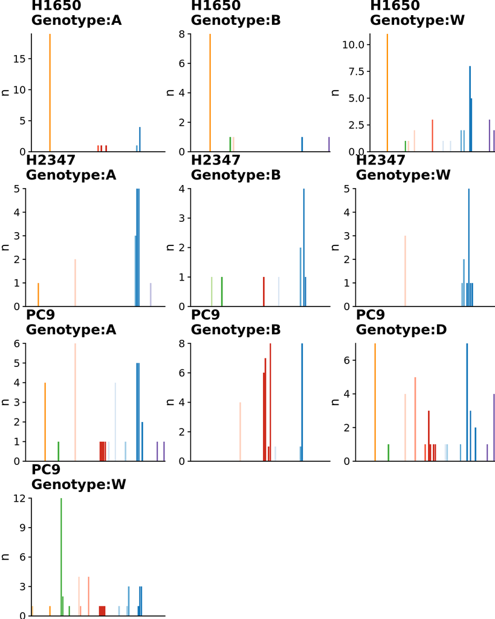

## Mutations present in non-lineage daughters

If two daughters derived from different single-cell clones share the same mutations, it is very likely that the mutation is either due to technical noise (explaining why it was reproduced), it was a pre-existing somatic mutation (which should be removed), or it is a hotspot mutation (which should be rare and can be rescued at a later time).

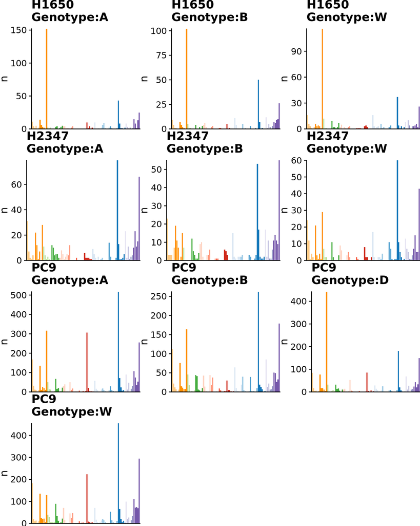

## Mutations present within multiple daughters of the same lineage

These mutations are either pre-existing somatic mutations, or they were acquired early during expansion of the parental colony resulting in a significant proportion of daughters acquiring them. If these mutations are indeed pre-existing, they would also need to somehow not be detected in any parents or in any daughters from other lineages. Given that this is very unlikely, we assume that these mutations are early-acquired mutations in the experiment and we keep them. The mutation profiles below also support this, as they are overall very similar to the unique mutation profiles shown earlier in this document.

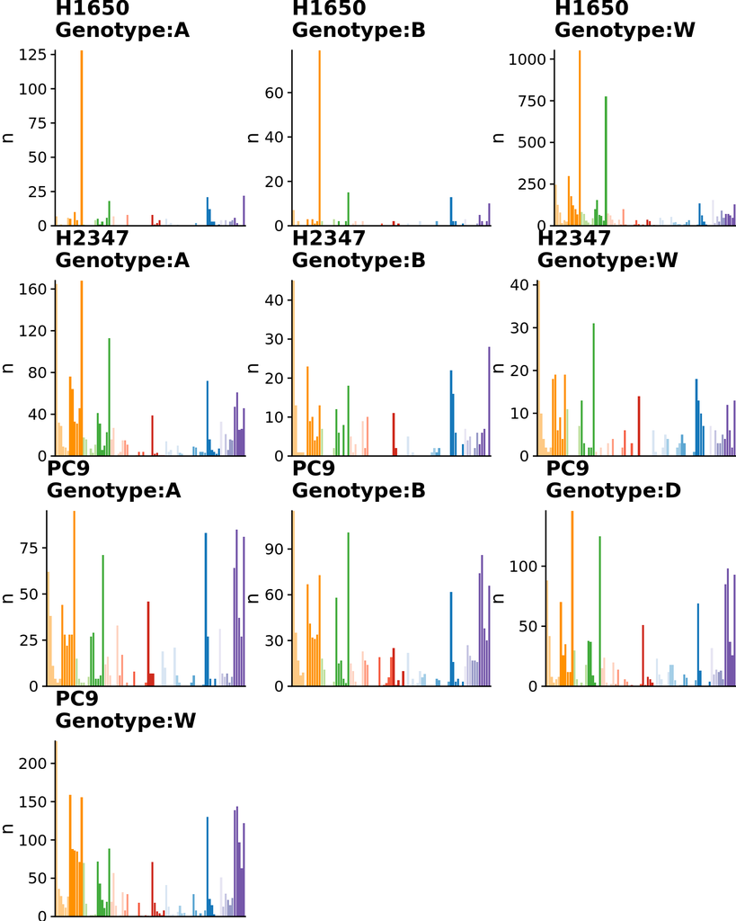